# 2. Partial or Full Liquidation into Cash

In this strategy, a portion of the portfolio is liquidated and the proceeds are invested at the Secured Overnight Financing Rate (SOFR). The remaining portfolio continues to track the performance of the constituent firms. For a full liquidation, all assets are converted to cash, eliminating exposure to market risk.

#### Literature Review - Liquidation and Exposure

In this scenario, partial liquidation maintains exposure to market risk, as the portfolio continues to hold the remaining stocks after the liquidation. The extent of the exposure, however, is reduced based on the percentage of the portfolio liquidated (25%, 50%, 75%, or 100%), with less exposure as the liquidation percentage increases. Full liquidation eliminates all market risk since the entirety of the assets are reallocated into cash. This ensures that, while some exposure persists in partial liquidation, it is significantly less compared to an unhedged position. The varying degrees of liquidation reduce the potential downside risk but also limit participation in any positive market movements.

#### Assumptions

**Tooling**

```python
pip install yfinance openpyxl pandas matplotlib
```

**Libraries**

```python
import yfinance as yf
import pandas as pd
import numpy as np
from datetime import datetime, timedelta
import matplotlib.pyplot as plt
import matplotlib.dates as mdates
import math as math
import copy
```

#### Constants

- The Secured Overnight Financing Rate (SOFR) data used in this analysis was sourced from the official New York Federal Reserve website: [SOFR Reference Rates](https://www.newyorkfed.org/markets/reference-rates/sofr).

**Data Required**

```python
file_path = 'Perishing_portfolio.xlsx'
sheet_name = 'portfolio'
evaluation_date = '2020-02-21'
days = 180
evaluation_date_next = datetime.strptime(evaluation_date, '%Y-%m-%d') + timedelta(days=days)
plot_x_axis_interval = days / 20
share_port = {}
share_nums = {}
share_price = {} # Share price at evaluation date (2020-01-31)
SOFR_RATE_CONS = 0.0171663

# Liquidation constants
QUARTER_LIQUIDATION = 0
HALF_LIQUIDATION = 1
THIRD_QUARTILE_LIQUIDATION = 2
FULL_LIQUIDATION = 3

QUARTER = 0.25
HALF = 0.50
THIRD_QUARTER = 0.75
FULL = 1
```

### 2.1 Value of Partially Liquidated Portfolio

Four scenarios will be investigated:

- Liquidation of 25%
- Liquidation of 50%
- Liduidation of 75%
- Full Liquidation

```python
def modifyNumShares(share_tracker, constant, soldShares):
    if (constant == QUARTER_LIQUIDATION):
        liquidation_fact = QUARTER
    elif (constant == HALF_LIQUIDATION):
        liquidation_fact = HALF
    elif (constant == THIRD_QUARTILE_LIQUIDATION):
        liquidation_fact = THIRD_QUARTER
    else:
        liquidation_fact = FULL

    for key in share_tracker:
        num_shares = share_tracker[key] #Get number of shares
        shares_sold = math.ceil(num_shares * liquidation_fact) #Apply the liqation factor
        soldShares[key] = shares_sold
        shares_remaning = num_shares - shares_sold
        share_tracker[key] = math.ceil(shares_remaning)
```

```
QUARTER LIQUIDATION
Shares Sold
{'CMG': 21547867, 'HLT': 2639202, 'LOW': 2153303, 'QSR': 3867046, 'BRK-B': 1003899, 'HHH': 1596709, 'A': 2201940, 'FNMA': 32751128, 'FMCC': 18002631}
Shares Remaining
{'CMG': 64643598, 'HLT': 7917603, 'LOW': 6459909, 'QSR': 11601135, 'BRK-B': 3011695, 'HHH': 4790126, 'A': 6605820, 'FNMA': 98253383, 'FMCC': 54007892}
Shares Price
{'CMG': 17.34, 'HLT': 107.7997, 'LOW': 116.24, 'QSR': 61.0098, 'BRK-B': 224.4301, 'HHH': 121.68, 'A': 82.5602, 'FNMA': 3.19, 'FMCC': 3.06}
CASH:  373640013.78
CASH:  658145197.6194
CASH:  908445138.3394
CASH:  1144372841.3902001
CASH:  1369677994.3501
CASH:  1563965545.4701
CASH:  1745758152.2581
CASH:  1850234250.5781
CASH:  1905322301.4380999
Cash Value:  1905322301.4380999
```

[output not shown]

```
HALF LIQUIDATION
Shares Sold
{'CMG': 43095733, 'HLT': 5278403, 'LOW': 4306606, 'QSR': 7734091, 'BRK-B': 2007797, 'HHH': 3193418, 'A': 4403880, 'FNMA': 65502256, 'FMCC': 36005262}
Shares Remaining
{'CMG': 43095732, 'HLT': 5278402, 'LOW': 4306606, 'QSR': 7734090, 'BRK-B': 2007797, 'HHH': 3193417, 'A': 4403880, 'FNMA': 65502255, 'FMCC': 36005261}
Shares Price
{'CMG': 17.34, 'HLT': 107.7997, 'LOW': 116.24, 'QSR': 61.0098, 'BRK-B': 224.4301, 'HHH': 121.68, 'A': 82.5602, 'FNMA': 3.19, 'FMCC': 3.06}
CASH:  747280010.22
CASH:  1316290270.0991
CASH:  1816890151.5391002
CASH:  2288745496.6309004
CASH:  2739355578.1206
CASH:  3127930680.3606005
CASH:  3491515893.9366007
CASH:  3700468090.5766006
CASH:  3810644192.2966003
Cash Value:  3810644192.2966003
```

[output not shown]

```
THIRD QUARTER LIQUIDATION
Shares Sold
{'CMG': 64643599, 'HLT': 7917604, 'LOW': 6459909, 'QSR': 11601136, 'BRK-B': 3011696, 'HHH': 4790127, 'A': 6605820, 'FNMA': 98253384, 'FMCC': 54007893}
Shares Remaining
{'CMG': 21547866, 'HLT': 2639201, 'LOW': 2153303, 'QSR': 3867045, 'BRK-B': 1003898, 'HHH': 1596708, 'A': 2201940, 'FNMA': 32751127, 'FMCC': 18002630}
Shares Price
{'CMG': 17.34, 'HLT': 107.7997, 'LOW': 116.24, 'QSR': 61.0098, 'BRK-B': 224.4301, 'HHH': 121.68, 'A': 82.5602, 'FNMA': 3.19, 'FMCC': 3.06}
CASH:  1120920006.66
CASH:  1974435342.5788002
CASH:  2725335164.7388
CASH:  3433118151.8716
CASH:  4109033386.3212004
CASH:  4691896039.6812
CASH:  5237273860.0452
CASH:  5550702155.0052
CASH:  5715966307.5852
Cash Value:  5715966307.5852
FULL LIQUIDATION
Shares Sold
{'CMG': 86191465, 'HLT': 10556805, 'LOW': 8613212, 'QSR': 15468181, 'BRK-B': 4015594, 'HHH': 6386835, 'A': 8807760, 'FNMA': 131004511, 'FMCC': 72010523}
Shares Remaining
{'CMG': 0, 'HLT': 0, 'LOW': 0, 'QSR': 0, 'BRK-B': 0, 'HHH': 0, 'A': 0, 'FNMA': 0, 'FMCC': 0}
Shares Price
{'CMG': 17.34, 'HLT': 107.7997, 'LOW': 116.24, 'QSR': 61.0098, 'BRK-B': 224.4301, 'HHH': 121.68, 'A': 82.5602, 'FNMA': 3.19, 'FMCC': 3.06}
Cash Value:  7621280000.0
```

[output not shown]

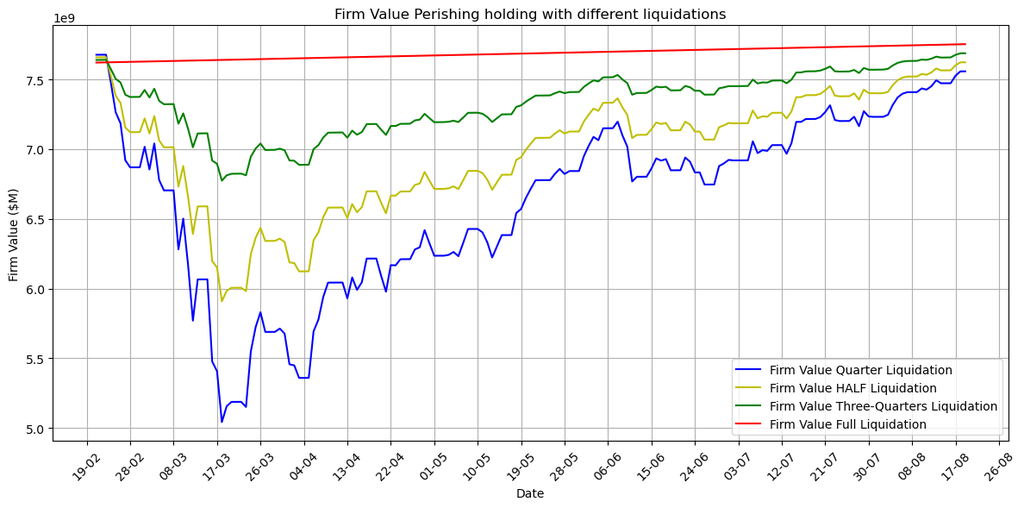

```python
df = pd.read_excel(file_path, sheet_name=sheet_name)
full_liquid = False
frame_arr = []
for index, row in df.iterrows():
    ticker = row['Ticker Code']
    shares = row['Number of Shares']
    price = row['Share price']
    share_port[ticker] = shares
    share_price[ticker] = round(price,  4)


final_value = 0
#Could place this into a for loop so that it graphs can all be graphed at once.
for loop in range(4):
    shares_sold = {}
    share_nums = copy.copy(share_port)
    if (loop == FULL_LIQUIDATION):
        print("FULL LIQUIDATION")
        modifyNumShares(share_nums, FULL_LIQUIDATION, shares_sold) # Method can be found above
        full_liquid = True
    elif (loop == THIRD_QUARTILE_LIQUIDATION):
        print("THIRD QUARTER LIQUIDATION")
        modifyNumShares(share_nums, THIRD_QUARTILE_LIQUIDATION, shares_sold)
    elif (loop == HALF_LIQUIDATION):
        print("HALF LIQUIDATION")
        modifyNumShares(share_nums, HALF_LIQUIDATION, shares_sold)
    elif (loop == QUARTER_LIQUIDATION):
        print("QUARTER LIQUIDATION")
        modifyNumShares(share_nums, QUARTER_LIQUIDATION, shares_sold)

    print("Shares Sold")
    print(shares_sold)
    print("Shares Remaining")
    print(share_nums)

    print("Shares Price")
    print(share_price)

    #Shares sold at shares price at 31-01-2020
    # Invested at the risk free rate.
    #TODO: Do the same thing but now apply the interest rates to liquid cash and the same as before
    cash_value = 0
    if (full_liquid):
        for index, row in df.iterrows():
            cash_value += row['Value (in $ million)']
        cash_value = cash_value * 1000000

    else:
        for key in shares_sold:
            cash_value += shares_sold[key] * share_price[key]
            print("CASH: ", cash_value)

    print("Cash Value: ", cash_value)
    values = np.zeros((days + 1,), dtype=float) #TO HOLD LIQUIDATION VALUES WITH INTEREST
    date_range = pd.date_range(start=evaluation_date, end=evaluation_date_next)

    portfolio_values = pd.DataFrame(index=date_range)
    for ticker in share_nums:
        historical_data = yf.download(ticker, start=evaluation_date, end=evaluation_date_next)["Adj Close"]
        shares = share_nums[ticker]
        if not historical_data.empty:
            daily_values = historical_data * shares
            portfolio_values[ticker] = daily_values


    portfolio_values.fillna(method='ffill', inplace=True)

    for day in range(0, days + 1):
        values[day] = cash_value * math.exp(SOFR_RATE_CONS * (day/days))
    frame = {'Liquidation Value': values}
    Liquidaion_values = pd.DataFrame(data=frame, index=date_range)
    portfolio_values['Liquidation Value'] = Liquidaion_values['Liquidation Value']

    portfolio_values['Firm Value'] = portfolio_values.sum(axis=1)
    frame_arr.append(portfolio_values)

plt.figure(figsize=(12, 6))
plt.plot(frame_arr[QUARTER_LIQUIDATION].index, frame_arr[QUARTER_LIQUIDATION]['Firm Value'], linestyle='-', color='b', label='Firm Value Quarter Liquidation')
plt.plot(frame_arr[HALF_LIQUIDATION].index, frame_arr[HALF_LIQUIDATION]['Firm Value'], linestyle='-', color='y', label='Firm Value HALF Liquidation')
plt.plot(frame_arr[THIRD_QUARTILE_LIQUIDATION].index, frame_arr[THIRD_QUARTILE_LIQUIDATION]['Firm Value'], linestyle='-', color='g', label='Firm Value Three-Quarters Liquidation')
plt.plot(frame_arr[FULL_LIQUIDATION].index, frame_arr[FULL_LIQUIDATION]['Firm Value'], linestyle='-', color='r', label='Firm Value Full Liquidation')
plt.title('Firm Value Perishing holding with different liquidations')
plt.xlabel('Date')
plt.ylabel('Firm Value ($M)')
plt.xticks(rotation=45)
plt.gca().xaxis.set_major_locator(mdates.DayLocator(interval=int(plot_x_axis_interval)))
plt.gca().xaxis.set_major_formatter(mdates.DateFormatter('%d-%m'))  # format it
plt.grid()
plt.legend()
plt.tight_layout()
plt.show()
```

### 2.2 Acknowledgements and Tooling

This work is licensed under the MIT License and is freely available for distribution. All rights are reserved by the authors DanielCiccC and UniversalTze.

- Various tools, including GitHub, GitHub Copilot, and ChatGPT, were utilised in the development and analysis of this project.
- Portions of the code were adapted from examples provided in lectures.

[output not shown]